# Hicks et al. - Tables

## F1 micro vs F1 macro

### F1 score

F1 scores are given by:

$$ F1_i = 2 \frac{Precision_i \times Recall_i}{Precision_i + Recall_i} $$

where $Precision_i = TP_i/(TP_i + FP_i)$, $Recall_i = TP_i/(TP_i+FP_i)$, and $i$ indexes a class.

**F1 micro equals accuracy!** For multi-class, F1 micro provides the same information provided by the accuracy. That is because F1 micro considers *all classes at once*, resulting in $ Recall = Precision $. Hence:

$$ F1 \, micro = 2 \frac{Precision \times Recall}{Precision + Recall} = 2 \frac{Precision^2}{Precision} = Precision$$

Furthermore:

$$ F1 \, micro = Precision = TP/(TP+FP) = Accuracy! \; Q.E.D.$$

### Aggregation choice: F1 macro vs F1 weighted

Really, the aggregation choice is between F1 macro and F1 weighted, where F1 macro is an unweighted aggregation of F1 scores. More formally:

$$ F1 = \sum_i{w_i \frac{TP}{TP + FP}} $$

When $w_i = 1$, we obtain an F1 macro and when $w_i = n_i$ we obtain an F1 weighted ($n_i$ is the sample proportion by label).

## Output

We can see that F1 micro is effectively equal to Accuracy in the multi-class case (see example below). Also, the aggregate metrics F1 macro and F1 weighted are different from accuracy. Therefore:

F1 macro is the **conservative choice** as it does not assign a larger weight to the most frequently occurring label.

```python
from sklearn.metrics import accuracy_score, f1_score, confusion_matrix, cohen_kappa_score, classification_report
import pandas as pd

df = pd.read_csv('EP2_RandModel319_RandSplit123_PRED_.csv', encoding='latin-1')  # read file

# predictions
y_true = df['label'].to_list()
y_pred = df['prediction_1'].to_list()

# metrics
print("F1 micro == accuracy")
print('Accuracy: {:.5f}'.format(accuracy_score(y_true, y_pred)))
print('F1 micro: {:.5f}'.format(f1_score(y_true, y_pred, average='micro')))

print("\n")
print("F1 macro is more conservative")
print('F1 macro: {:.5f}'.format(f1_score(y_true, y_pred, average='macro')))
print('F1 weighted: {:.5f}'.format(f1_score(y_true, y_pred, average='weighted')))

#cohen_kappa_score()
```

```
F1 micro == accuracy
Accuracy: 0.89042
F1 micro: 0.89042


F1 macro is more conservative
F1 macro: 0.87086
F1 weighted: 0.89002
```

That would be slightly **different from what we currently have**. Please check the *Recommendations* and let me know if that's what we want.

```python
report_dict = classification_report(y_true, y_pred, output_dict=True)
report_df = pd.DataFrame(report_dict).transpose().astype({"support": int})
report_df.loc['accuracy', 'support'] = ''
report_df.round(2)
```

|  | precision | recall | f1-score | support |
| --- | --- | --- | --- | --- |
| Other | 0.80 | 0.89 | 0.84 | 64 |
| education & research | 0.90 | 0.92 | 0.91 | 682 |
| governance | 0.91 | 0.93 | 0.92 | 1053 |
| info activity | 0.85 | 0.81 | 0.83 | 379 |
| personal | 0.92 | 0.87 | 0.89 | 337 |
| professional | 0.84 | 0.82 | 0.83 | 314 |
| accuracy | 0.89 | 0.89 | 0.89 |  |
| macro avg | 0.87 | 0.87 | 0.87 | 2829 |
| weighted avg | 0.89 | 0.89 | 0.89 | 2829 |

## Additional Metrics

We might consider two additional metrics: Cohen's K and Matthews Correlation Coefficient. However, the second metric is really a correlation coefficient between predicted and grand truth cases, hence it is not suitable for multi-class classifiers.

Cohen's K is a clever metric that considers *trues occurring by chance* alone:

$$Cohen's K = \frac{Agree - AgreeByChance}{1-AgreeByChance} $$

For an exhaustive explanation of what Cohen's K is and the notion of agreement by chance, please refer to [this post](https://towardsdatascience.com/multi-class-metrics-made-simple-the-kappa-score-aka-cohens-kappa-coefficient-bdea137af09c).

# Recommendations

Here's how Asensio et al. (2020) present results in their *Nature* paper.

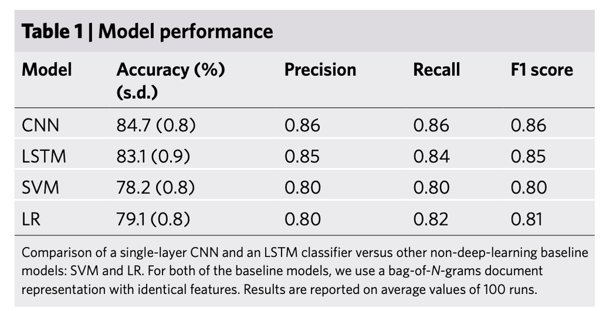

```python
from IPython.display import Image
Image(filename='asensio2020.png')
```

**Table 1 (Results)**. In comport with the Asensio et al. (2020) presentation and re-arranging sklearn's *classification's report()*, we might present our results as follows. The main changes from the prior version of the table are in green.

[output not shown]

> Table 1. 6-category classification: Performance metrics for test set. Results are reported on average values of 10 runs of the best-performing model: batch size 8, learning rate 1e-3, warmup steps 500, warmup cosine, weight decay 1e-4, training epochs 2.

**Table 2 (CV)**. This table presents cross-validations. I would only report F1 scores for clarity. We might include only a subset of the discussed CV measures, none, or all of them. Two of them have been proposed by Dr Asensio, and the last two are Dr Hicks' additions.

- Model cross-validation: 10-run average for runs which only change for the neural network's seeds (same information reported in parentheses for Table 1);
- Set cross-validation: 10-run average for runs which only change for the test set;
- Training cross-validation: 10-run average for runs which re-allocate observations across the train and validation set while holding the test set constant;
- Total cross-validation: 10-run average for runs which vary on all of the above.

[output not shown]

1. I propose the following text for captioning:

> Table 2. 6-category classification: Cross-validations with respect to neural network initialization (Neural Network), train-test split (Test), train-validation split (Training), and all of the above (Total). Results are reported on average values of 10 runs of the best-performing model: batch size 8, learning rate 1e-3, warmup steps 500, warmup cosine, weight decay 1e-4, training epochs 2.